# NEH Grants Project

D Conner

11/22/2021

# Introduction

## About the Data

The data set is grant data from the US National Endowment for the Humanities (NEH). Data were downloaded 10/16/2021 [1] as CSV files for each decade from the 1960s through the 2020s, and according to the info page last updated 8/3/2020. [2] The latter site also includes a data dictionary, NEH_GrantsDictionary, and a contextual reference for the NEH’s larger structure and programs, NEH_GrantsReference.

According to the reference document, the NEH was founded by an act of Congress in 1965. They grant funding to organizations and individuals to support research, education, and preservation concerning the humanities, particularly American history and culture as a diverse and living collection of fields.

[1] https://catalog.data.gov/organization/neh-gov  
[2] https://securegrants.neh.gov/open/data/

## Primary question

Who are grants awarded to and in what fields? How do award amounts compare to amounts dispensed, and what factors might impact this result?

## Analysis Approach

Concatenate data for the duration of the program, 1966-2021.

Summarize organization type, award amounts, and disciplines over time and create a suitable visualization.

Show overall distribution of award amounts by decade. Compare award authorization (outright + match) to amount dispensed (outright + match + supplement). This is possibly best evaluated as percent of initial authorization due to wide range of dollar amounts.

What percent of awards are on, below, and above initial authorization? Do these ratios change over time? What are the roles of matching and supplemenatal funds, and do they trend with other data within the table?

Communicate results of these explorations with suitable visualizations.

## Load Packages, Scripts & Data

```r
#packages prep
if(! require("pacman")) install.packages("pacman")
pacman::p_load(
  tidyverse,
  here,
  readr,
  lubridate
)
```

```r
# load script for data import & cleaning
source(here::here("Scripts", "load_data.R"))

# load analysis functions
source(here::here("Scripts", "functions.R"))  # placeholder
```

```r
# create list of file names
files <- list.files(here::here("Data"), pattern = "\\.csv", full.names = T)

# import file data
grants_df <- map_df(files, ~read_data(.))
```

```
## Warning: One or more parsing issues, see `problems()` for details

## Warning: One or more parsing issues, see `problems()` for details
```

```r
glimpse(grants_df)   # use head() for presentation display
```

```
## Rows: 67,153
## Columns: 33
## $ AppNumber             <chr> "FB-10007-68", "FB-10009-68", "FB-10015-68", "FB~
## $ ApplicantType         <chr> "2", "2", "2", "2", "2", "2", "2", "2", "2", "2"~
## $ Institution           <chr> "Regents of the University of California, Berkel~
## $ OrganizationType      <chr> "Four-Year College", "Four-Year College", "Unive~
## $ InstCity              <chr> "Berkeley", "Claremont", "Riverside", "Boston", ~
## $ InstState             <chr> "CA", "CA", "CA", "MA", "PA", "MA", "MA", "MA", ~
## $ InstPostalCode        <chr> "94704-5940", "91711-6101", "92521-0001", "02115~
## $ InstCountry           <chr> "USA", "USA", "USA", "USA", "USA", "USA", "USA",~
## $ CongressionalDistrict <int> 13, 27, 41, 7, 3, 1, 7, 2, 1, 10, 6, 3, 3, 2, 5,~
## $ Latitude              <chr> "37.87029", "34.10373", "33.97561", "42.3395", "~
## $ Longitude             <chr> "-122.26813", "-117.70701", "-117.33113", "-71.0~
## $ CouncilDate           <chr> "11/1/1967", "11/1/1967", "11/1/1967", "11/1/196~
## $ YearAwarded           <int> 1967, 1967, 1967, 1967, 1967, 1967, 1967, 1967, ~
```

[output cut: 20 more lines]

All 33 columns are aligned and most are properly detected. Dates and map coordiantes are read as characters to silence a read parsing error due to format. These will be converted to proper format in the data cleaning procedure. Two persistent warnings for parsing issues remain, but `problems()` yields a blank result. This is sufficient to proceed.

# Data cleaning

Data cleaning steps were conducted to include correction of “no data”-type entries to functional `NA`s, extraction of first 5 digits of postcode, and coercion of correct data types for Latitude, Longitide, and CouncilDate.

```r
# data cleaning

grants_df_clean <-
grants_df %>%
   # replace functional NAs with uniform NAs
   mutate(ProjectDesc = str_replace(ProjectDesc, "No description", NA_character_)) %>%
   mutate(Supplements = str_replace(Supplements, "NULL", NA_character_)) %>%
   mutate(Disciplines = str_replace(Disciplines, "[Uu]nknown", NA_character_)) %>%
   mutate(Latitude = str_replace(Latitude, "[Uu]nknown", NA_character_)) %>%
   mutate(Longitude = str_replace(Longitude, "[Uu]nknown", NA_character_)) %>%
   mutate(ProjectDesc = str_replace(ProjectDesc, "No description", NA_character_)) %>%
   mutate(ToSupport = str_replace(ToSupport, "No to support statement", NA_character_)) %>%
   mutate(ProjectTitle = str_replace(ProjectTitle, "Title not available", NA_character_)) %>%
   mutate(CouncilDate = str_replace(CouncilDate, "1/1/1900", NA_character_)) %>%
   mutate(CouncilDate = str_replace(CouncilDate, "1900-01-01", NA_character_)) %>%


   # clean post codes: mixed 5-digit and 9-digit to first-5 digits
   # shortest ZIP codes are 3 digits without leading 0s
   mutate(InstZIP5 = str_extract(InstPostalCode, "\\d{3,5}")) %>%
   # clean post codes: pad out 3 & 4 digit codes to 5-digit standard
   mutate(InstZIP5 = str_pad(InstZIP5, 5, side = "left", "0")) %>%
   # clean post codes: change 00000 to NA
   mutate(InstZIP5 = str_replace(InstZIP5, "0{5}", NA_character_)) %>%

   # correct field classes
   mutate(Latitude = as.double(Latitude),
          Longitude = as.double(Longitude),
          CouncilDate = as.Date(CouncilDate, "%m/%d/%y"),
          BeginGrant = as.Date(BeginGrant, "%m/%d/%y"),
          EndGrant = as.Date(EndGrant, "%m/%d/%y"))
```

# Initial data characterization

The initial look at data incudes a `glimpse` of content & quick view of the data summary.

```r
glimpse(grants_df_clean)
```

```
## Rows: 67,153
## Columns: 34
## $ AppNumber             <chr> "FB-10007-68", "FB-10009-68", "FB-10015-68", "FB~
## $ ApplicantType         <chr> "2", "2", "2", "2", "2", "2", "2", "2", "2", "2"~
## $ Institution           <chr> "Regents of the University of California, Berkel~
## $ OrganizationType      <chr> "Four-Year College", "Four-Year College", "Unive~
## $ InstCity              <chr> "Berkeley", "Claremont", "Riverside", "Boston", ~
## $ InstState             <chr> "CA", "CA", "CA", "MA", "PA", "MA", "MA", "MA", ~
## $ InstPostalCode        <chr> "94704-5940", "91711-6101", "92521-0001", "02115~
## $ InstCountry           <chr> "USA", "USA", "USA", "USA", "USA", "USA", "USA",~
## $ CongressionalDistrict <int> 13, 27, 41, 7, 3, 1, 7, 2, 1, 10, 6, 3, 3, 2, 5,~
## $ Latitude              <dbl> 37.87029, 34.10373, 33.97561, 42.33950, 39.95298~
## $ Longitude             <dbl> -122.26813, -117.70701, -117.33113, -71.09048, -~
## $ CouncilDate           <date> 2019-11-01, 2019-11-01, 2019-11-01, 2019-11-01,~
## $ YearAwarded           <int> 1967, 1967, 1967, 1967, 1967, 1967, 1967, 1967, ~
```

[output cut: 21 more lines]

```r
summary(grants_df_clean)
```

```
##   AppNumber         ApplicantType      Institution        OrganizationType
##  Length:67153       Length:67153       Length:67153       Length:67153
##  Class :character   Class :character   Class :character   Class :character
##  Mode  :character   Mode  :character   Mode  :character   Mode  :character
##
##
##
##
##    InstCity          InstState         InstPostalCode     InstCountry
##  Length:67153       Length:67153       Length:67153       Length:67153
##  Class :character   Class :character   Class :character   Class :character
##  Mode  :character   Mode  :character   Mode  :character   Mode  :character
##
##
##
##
##  CongressionalDistrict    Latitude        Longitude        CouncilDate
##  Min.   : 0.000        Min.   :-14.28   Min.   :-170.72   Min.   :2019-01-01
##  1st Qu.: 1.000        1st Qu.: 37.35   1st Qu.: -93.24   1st Qu.:2019-02-01
##  Median : 4.000        Median : 40.35   Median : -81.93   Median :2019-05-01
##  Mean   : 7.342        Mean   : 39.21   Mean   : -87.22   Mean   :2019-05-11
##  3rd Qu.:11.000        3rd Qu.: 42.05   3rd Qu.: -74.43   3rd Qu.:2019-08-01
##  Max.   :99.000        Max.   : 71.29   Max.   : 145.74   Max.   :2019-11-01
##                        NA's   :12828    NA's   :12828     NA's   :51772
##   YearAwarded   ProjectTitle         Program            Division
##  Min.   :1966   Length:67153       Length:67153       Length:67153
##  1st Qu.:1980   Class :character   Class :character   Class :character
##  Median :1988   Mode  :character   Mode  :character   Mode  :character
##  Mean   :1991
##  3rd Qu.:2001
##  Max.   :2021
##
##  ApprovedOutright  ApprovedMatching  AwardOutright     AwardMatching
##  Min.   :      0   Min.   :      0   Min.   :   -486   Min.   :      0
##  1st Qu.:   3500   1st Qu.:      0   1st Qu.:   3500   1st Qu.:      0
##  Median :  20000   Median :      0   Median :  18707   Median :      0
##  Mean   :  76170   Mean   :  16221   Mean   :  73296   Mean   :  14883
##  3rd Qu.:  55993   3rd Qu.:      0   3rd Qu.:  52632   3rd Qu.:      0
##  Max.   :8711590   Max.   :6000000   Max.   :7254650   Max.   :6000000
##
```

[output cut: 17 more lines]

```
##  Length:67153       Min.   : 0.000   Length:67153       Min.   : 0.000
##  Class :character   1st Qu.: 1.000   Class :character   1st Qu.: 1.000
##  Mode  :character   Median : 1.000   Mode  :character   Median : 1.000
##                     Mean   : 1.019                      Mean   : 1.196
##                     3rd Qu.: 1.000                      3rd Qu.: 1.000
##                     Max.   :12.000                      Max.   :10.000
##
##  Disciplines          InstZIP5
##  Length:67153       Length:67153
##  Class :character   Class :character
##  Mode  :character   Mode  :character
##
##
##
##
```

Based on these data, we can already start to see how we may need to look at the data. A typical award amount of $20,000 but maximum of $8.7 million strongly suggests that award amounts will be best plotted on a log scale and analyzed as a proportion of the original approved amount.

This summary also indicates that YearAwarded will be the most useful as a time axis. Additional date fields CouncilDate, BeginGrant, and EndGrant are all clearly missing data.

The `peek_NEH` custom function summarizes column and data type as well as the number of distinct values, NA, and entries with the value “unknown”.

```r
grants_df_clean %>%
    map_dfr(peek_NEH,
           .id = "field")
```

| field | class | n_distinct | n_NA | n_unknown |
| --- | --- | --- | --- | --- |
| AppNumber | character | 67153 | 0 | 0 |
| ApplicantType | character | 2 | 0 | 0 |
| Institution | character | 8886 | 0 | 1594 |
| OrganizationType | character | 41 | 0 | 10330 |
| InstCity | character | 3169 | 0 | 171 |
| InstState | character | 58 | 0 | 0 |
| InstPostalCode | character | 9422 | 1 | 603 |
| InstCountry | character | 41 | 0 | 454 |
| CongressionalDistrict | integer | 55 | 0 | 0 |
| Latitude | numeric | 6336 | 12828 | 0 |

[output cut: 24 more lines]

Some columns have a expectedly large or small number of distinct values. For example, AppNumber is unique for all entries while ParticipantCount reflects the limited number of official recipient agency contacts even in large collaborations.

Histograms might also be helpful to understand the shape of the data. The `create_hist` and `create_hist_log` functions plot histograms of the input list of fields on a linear or log axis, respectively.

```r
# create lists of numeric fields
date_fields <-
       c("CouncilDate", "YearAwarded")

money_fields <-
    c("ApprovedOutright", "ApprovedMatching", "OriginalAmount", "SupplementAmount")
```

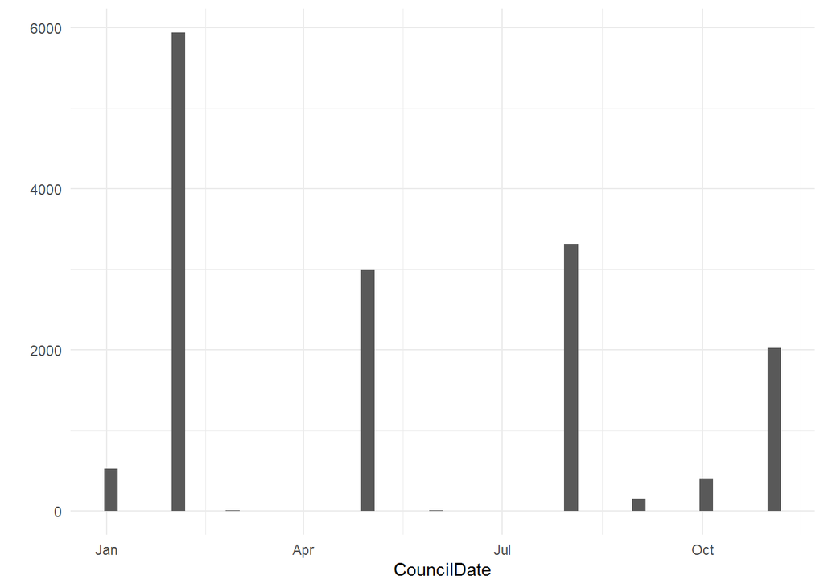

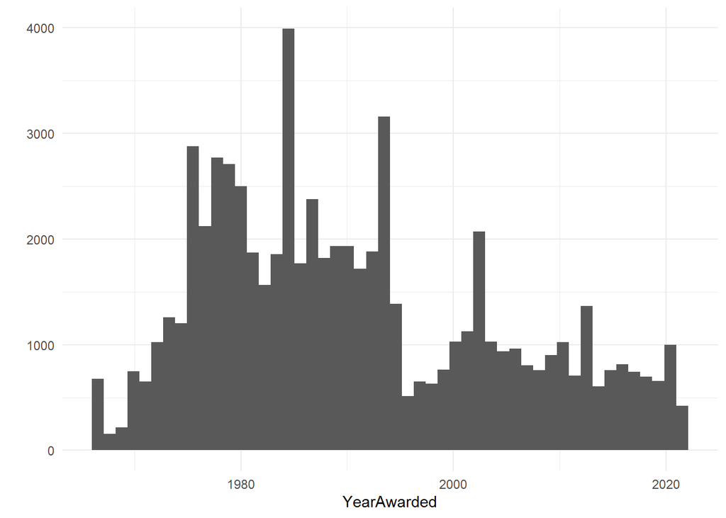

```r
# map histogram function to date fields related to award approval/start
map(date_fields,
    ~ create_hist(grants_df_clean , .x)
    )
```

The YearAwarded data show a rapid initial rise in number of grants awarded through the late 1970s. The peak of grant activity was largely maintained through the late 1980s and early 1990s, followed by a steep dropoff in the late 1990s. Grant activity recovered inthe early 2000s only to slowly fall again to the present. The most recent year, 2021, is particularly low due to incomplete data.

According to the data dictionary, some grants of the unknown CouncilDate may be Chairman’s Grants which are awarded by the chairman outside of the regular granting cycle and without a council review. However, this is most pertinent to data after 1971 when CouncilDate started to be included in the data record.

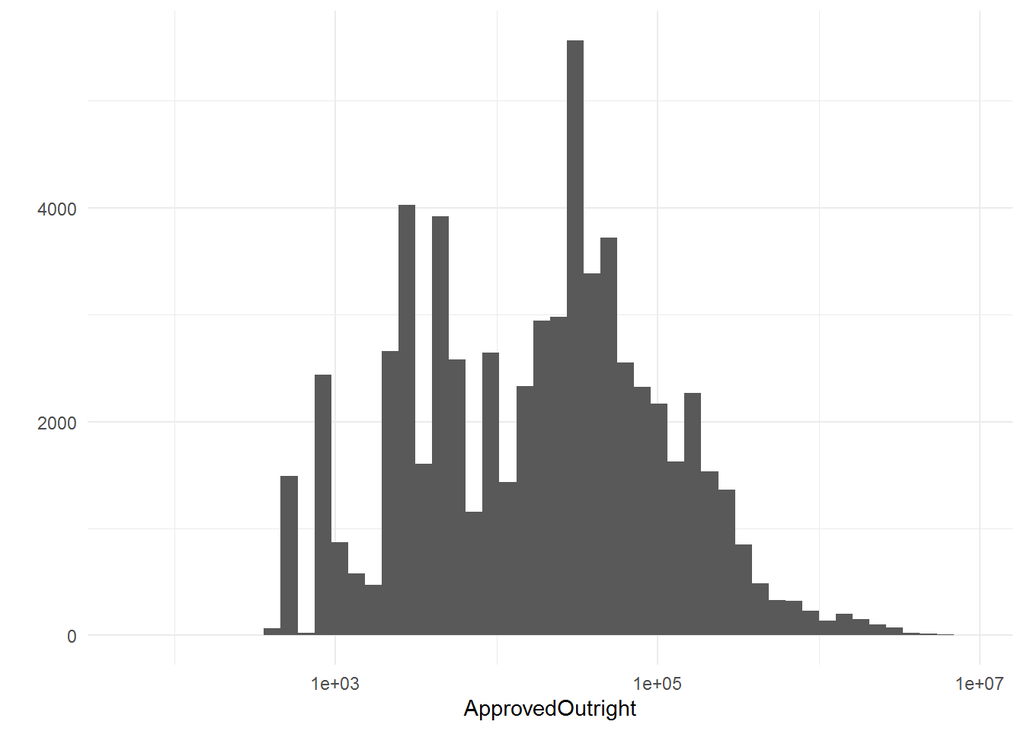

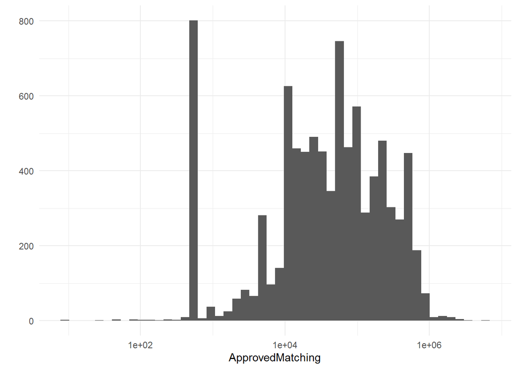

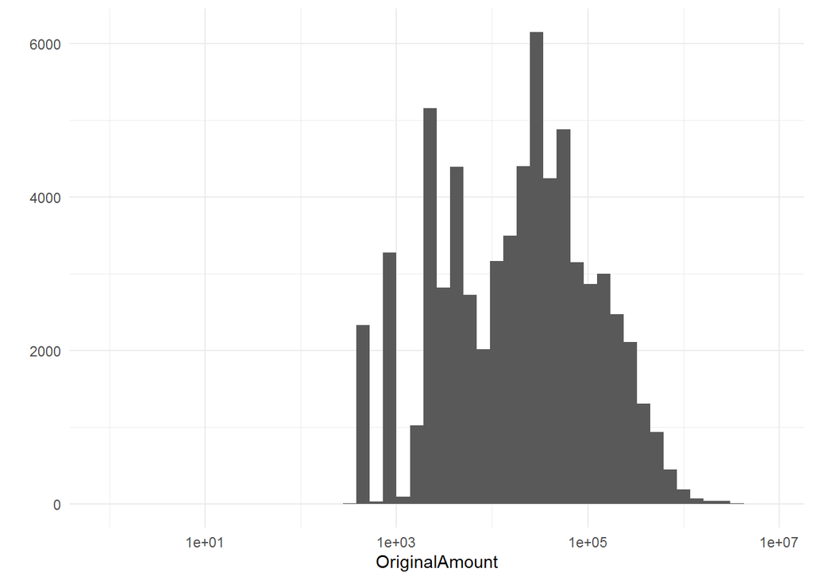

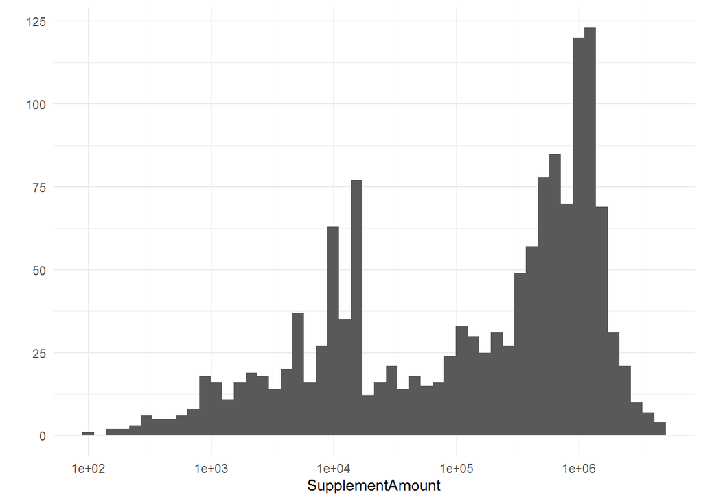

```r
# map histogram function to award amount-related fields w log scale
map(money_fields,
    ~ create_hist_log(grants_df_clean , .x)
    )
```

## Aside: What’s up with the Invalid ZIP Codes?

After cleaning to extract 5-digit ZIP Codes, there are 855 NA values. However, in the data peek at the as-is InstPostalCode column we saw 1 NA and 603 Unknown. What are the rest?

```r
grants_df_clean %>%
   filter(is.na(InstZIP5)) %>%
   filter(!InstPostalCode == "Unknown") %>%
   select(AppNumber, YearAwarded, InstPostalCode, InstCountry, InstZIP5)
```

| AppNumber | YearAwarded | InstPostalCode | InstCountry | InstZIP5 |
| --- | --- | --- | --- | --- |
| FB-10182-67 | 1967 | T6G 2H4 | Canada | NA |
| FB-20267-67 | 1967 | H3A 2T5 | Canada | NA |
| FT-10257-67 | 1967 | 00000-0000 | USA | NA |
| FT-10310-68 | 1967 | 00000-0000 | USA | NA |
| RO-10263-68 | 1968 | WC1E 7HU | United Kingdom | NA |
| FB-*0046-79 | 1978 | 0 | USA | NA |
| FB-*0142-79 | 1978 | CB2 1TN | UNITED KINGDOM | NA |
| FR-*0001-79 | 1978 | 0 | USA | NA |
| FR-*0009-79 | 1978 | 0 | USA | NA |
| FR-*0010-79 | 1978 | 0 | USA | NA |

[output cut: 241 more lines]

Removing the Unknown Postcodes, we see two reasons for NA results. The data cleaning routine pulls 3-5 consecutive numeric digits and left-pads 0s to ensure a 5-digit final result consistent with US postal codes. Some codes with no data were entered as 0s, which were also cleaned to NA. Finally, foreign alphanumeric postcodes would not be detected by this routine. The presence of foreign postcodes is also hinted at by the 41 entries for country and 58 for states.

As a quick aside, how many and where are the foreign grants going?

```r
grants_df_clean %>%
   filter(is.na(InstZIP5)) %>%
   filter(!InstCountry == "Unknown",
          !InstCountry == "USA") %>%
   group_by(InstCountry) %>%
   summarise(count = n(), sum(OriginalAmount))  %>%
   arrange(desc(count)) %>%
   ungroup()
```

| InstCountry | count | sum(OriginalAmount) |
| --- | --- | --- |
| Canada | 98 | 3936308.25 |
| United Kingdom | 30 | 777991.62 |
| Israel | 19 | 576346.00 |
| France | 7 | 300400.00 |
| Australia | 3 | 42052.00 |
| England | 3 | 86800.00 |
| Germany | 3 | 119900.00 |
| Argentina | 1 | 86500.00 |
| Brazil | 1 | 60000.00 |
| China | 1 | 55375.19 |

[output cut: 11 more lines]

# Grant Analysis Part 1: Distribution over time

## Setup: Calculations

First, we need to add some additional calculated data columns to ensure we can do the desired comparisons quickly. The resulting dataframe is renamed to a new object, grants_df_calcs.

```r
grants_df_calcs <-
 grants_df_clean %>%

   # sum total approved amount
   mutate(ApprovedInit = ApprovedOutright + ApprovedMatching)  %>%

   # sum final total disbursed
   mutate(AwardTotal = OriginalAmount + SupplementAmount) %>%

   # Add cols for Award % of init approved amount
   mutate(AwardOriginal_pct = 100 * AwardTotal / ApprovedInit) %>%
   mutate(AwardTotal_pct = 100 * AwardTotal / ApprovedInit) %>%
   mutate(Suppl_pct = 100 * SupplementAmount / ApprovedInit) %>%

   # Add col for decade for addl time grouping
   mutate(Decade = case_when(
                     YearAwarded >= 1960 & YearAwarded <= 1969 ~ "1960-1969",
                     YearAwarded >= 1970 & YearAwarded <= 1979 ~ "1970-1979",
                     YearAwarded >= 1980 & YearAwarded <= 1989 ~ "1980-1989",
                     YearAwarded >= 1990 & YearAwarded <= 1999 ~ "1990-1999",
                     YearAwarded >= 2000 & YearAwarded <= 2009 ~ "2000-2009",
                     YearAwarded >= 2010 & YearAwarded <= 2019 ~ "2010-2019",
                     YearAwarded >= 2020 & YearAwarded <= 2029 ~ "2020-2029"
                     )
         ) %>%

      # Add logical eval around matching grants
   mutate(MatchReqd = case_when(
                     ApprovedMatching > 0 ~ TRUE,
                     ApprovedMatching <= 0 ~ FALSE)
         ) %>%

      mutate(MatchMet = case_when(
                     MatchReqd == FALSE ~ NA,
                     MatchReqd == T & AwardMatching >= ApprovedMatching ~ TRUE,
                     MatchReqd == T & AwardMatching < ApprovedMatching ~ FALSE
                     )
         )
```

## First look at grants over time

To build on the histogram showing YearAwarded above (reproduced here for reference), looking at total award amount of grants by decade should give us some insight into trends in award over time.

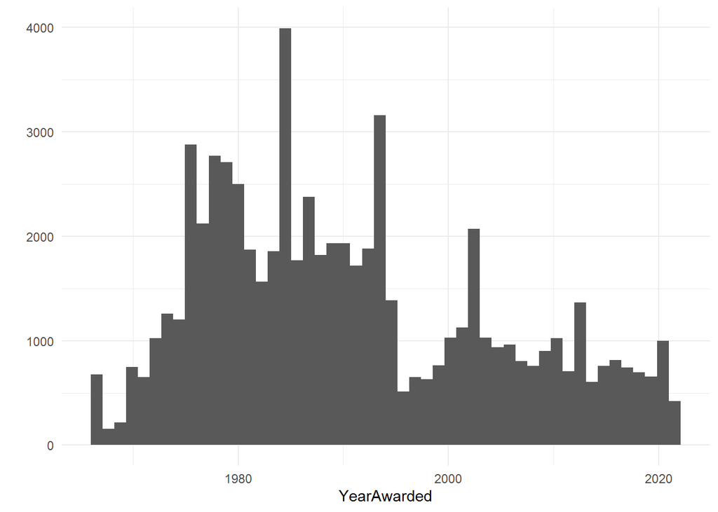

```r
create_hist(grants_df_calcs, "YearAwarded")
```

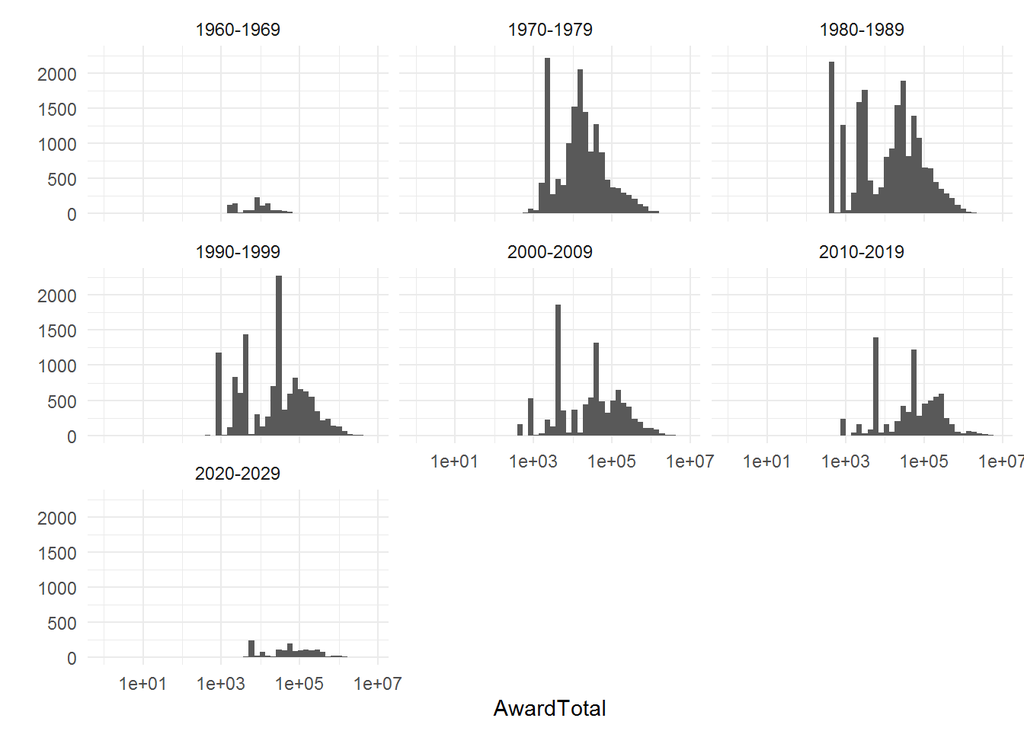

```r
create_hist_log_facet(grants_df_calcs, "AwardTotal", "Decade")
```

Indeed, each decade of grant award amounts looks distinct. In the 1960s, awards were few and small, which is understandable for a fledgling grant program. The 1970s and 1980s saw high activity and a broad range of grant amounts, from $1000 to over $1 million. The 1990s show similar distribution of amounts but reduced overall number of awards. The 2000s to the present show a trend for further decrease in number of awards with increasing award amounts.

Examining data by decades flattens the effect of financial crises, which usually last for at most 1-2 years. The trend of decreasing number of awards and tendency away from smaller grants - intuitively more likely to go to individual scholars and artists - reflect the politicization of the budget of the NEH since the mid-1990s, along with other agencies charged with funding arts and culture.

```r
decade_count_amt <-
grants_df_calcs %>%
   group_by(Decade) %>%
   summarise(count = n(), "Total Awarded" = sum(AwardTotal), "Avg Award" = mean(AwardTotal), "Median Award" = median(AwardTotal)) %>%
   arrange(Decade) %>%
   ungroup()

decade_count_amt
```

| Decade | count | Total Awarded | Avg Award | Median Award |
| --- | --- | --- | --- | --- |
| 1960-1969 | 1049 | 13943595 | 13292.27 | 8387.0 |
| 1970-1979 | 15362 | 821543663 | 53478.95 | 15611.5 |
| 1980-1989 | 19687 | 1131735678 | 57486.45 | 16500.0 |
| 1990-1999 | 12636 | 1182785319 | 93604.41 | 30000.0 |
| 2000-2009 | 9619 | 1083892684 | 112682.47 | 35000.0 |
| 2010-2019 | 7380 | 1138382239 | 154252.34 | 50400.0 |
| 2020-2029 | 1420 | 199299283 | 140351.61 | 60000.0 |

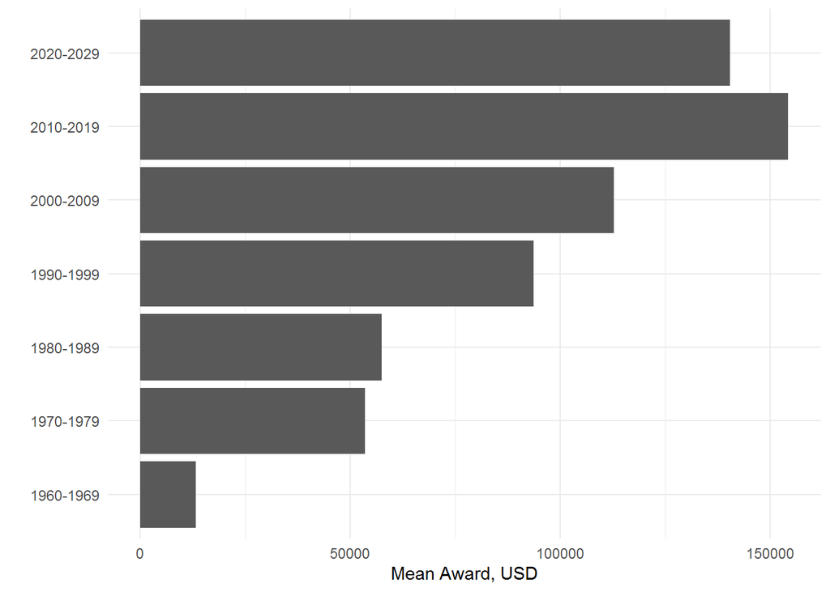

```r
decade_count_amt %>%
   create_barplot("Avg Award", "Decade", "Mean Award, USD")
```

# Grant Analysis Part 2: Who gets it?

## Who are grant recipients

Summarizing the OrganizationType and ranking by count, we can start to characterize what types of groups NEH grants go to.

```r
grants_df_calcs %>%
   group_by(OrganizationType) %>%
   summarise(count = n()) %>%
   arrange(desc(count)) %>%
   ungroup()
```

| OrganizationType | count |
| --- | --- |
| Four-Year College | 15971 |
| University | 15358 |
| Unknown | 10330 |
| Center For Advanced Study/Research Institute | 3831 |
| Publishing | 2982 |
| State Humanities Council | 2189 |
| National Organization | 2019 |
| Two-Year College | 1867 |
| Library | 1699 |
| Museum | 1656 |

[output cut: 31 more lines]

About 15% of the grants list the recipient organization type as unknown. The first check is whether these were individual awards rather than organizational.

```r
grants_df_calcs %>%
   filter(OrganizationType == "Unknown") %>%
   group_by(Decade, ApplicantType) %>%
   summarise(count = n()) %>%
   arrange(desc(count)) %>%
   ungroup()
```

| Decade | ApplicantType | count |
| --- | --- | --- |
| 1980-1989 | 2 | 4686 |
| 1990-1999 | 2 | 3184 |
| 1970-1979 | 2 | 1267 |
| 1970-1979 | 1 | 400 |
| 2000-2009 | 2 | 295 |
| 2010-2019 | 2 | 171 |
| 2000-2009 | 1 | 145 |
| 2010-2019 | 1 | 62 |
| 1960-1969 | 1 | 35 |
| 1960-1969 | 2 | 34 |

[output cut: 4 more lines]

The vast majority of the “Unknown” Organization Types - 93% - are of Type 2, which corresponds to individual grants. The only periods in which the values for the two applicant types are similar is the 1960s and 2020s. As noted above, data in general has more missing values during the earliest era of the NEH grant program. The 2020s have the fewest grants to date, but also the least missing data. A decreasing trend for Unknown organization type over time also likely is related to implementation of automated data collection as part of the application process that is less tolerant of omissions.

```r
grants_df_calcs %>%
   mutate(AppTotal = length(ApplicantType)) %>%
   group_by(ApplicantType, AppTotal) %>%
   summarise(TypeCount = n() ) %>%
   mutate(TypePercent = 100 * TypeCount / AppTotal) %>%
   arrange(desc(TypeCount)) %>%
   ungroup()
```

| ApplicantType | AppTotal | TypeCount | TypePercent |
| --- | --- | --- | --- |
| 1 | 67153 | 39965 | 59.51335 |
| 2 | 67153 | 27188 | 40.48665 |

Overall, 59.5% of grants are awarded to organizations and 40.5% to individuals. Are there differences int he grant amounts between the two applicant types?

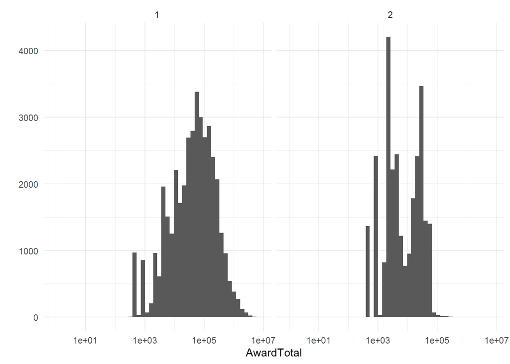

```r
create_hist_log_facet(grants_df_calcs, "AwardTotal", "ApplicantType")
```

Plotting award amount separated by ApplicantType shows drastic differences in the distributions. For type 1, organizations, the distribution is close to normal with a slight leftward skew toward lower award amounts vs higher and a range from $500 to $5 million. For type 2, individuals, the distribution is narrow and bimodal with peaks around $2,000 and $30,000.Individual grants also have a sharp drop-off at amounts over $70,000.

Revisiting the initial look at how the overall award amount distribution shifted over time: Has the distribution of grants to each applicant type changed over time?

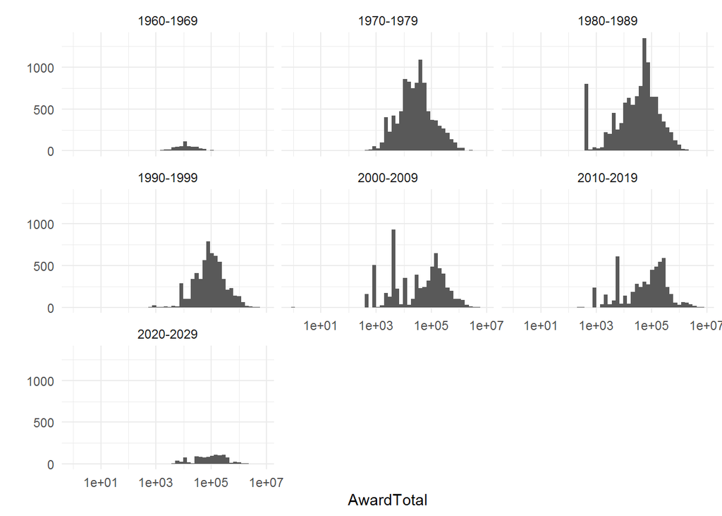

```r
# Organizations
grants_df_calcs %>%
   filter(ApplicantType == "1") %>%
   create_hist_log_facet("AwardTotal", "Decade")
```

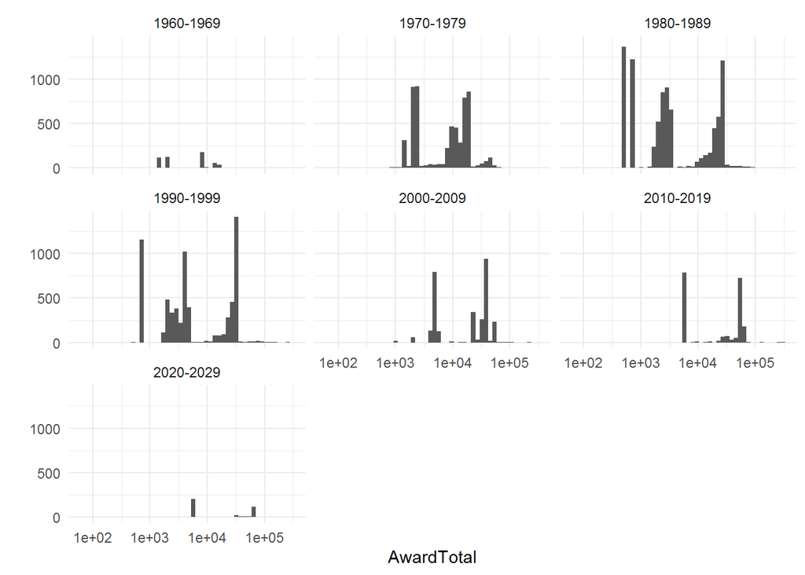

```r
# Individuals
grants_df_calcs %>%
   filter(ApplicantType == "2") %>%
   create_hist_log_facet("AwardTotal", "Decade")
```

For individual grantees, the primary change over time has been a decrease in total awards granted with distribution and amounts remaining largely similar.

The plots for organizational grants show a significant shift in distribution over time. From the 1960s through 1990s, the distribution shape is relatively normal with the mean shifting slightly upwards each decade. The 2000s show instead overlapping trends for a) an upward and normal distribution of large grants and b) an emerging cohort of small grants giving a leftward skew to the distribution as a whole.

## Location, location, location!

First, let’s look at the number of grants awarded by state. There are 58 state codes entered (inclusive of US territories and foreign jurisdictions), but let’s focus on the 10 each that get the most and least.

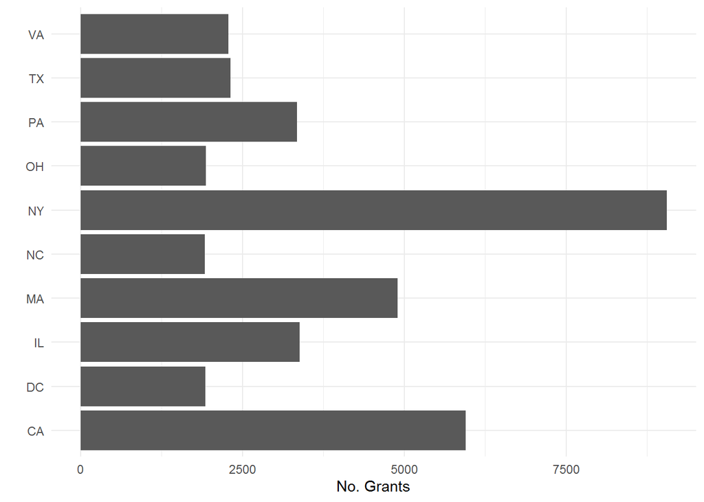

```r
# Most grants received
grants_df_calcs %>%
   group_by(InstState) %>%
   summarize(NState = length(InstState)) %>%
   ungroup() %>%
   slice_max(NState, n = 10) %>%
   create_barplot("NState", "InstState", xlabel = "No. Grants")
```

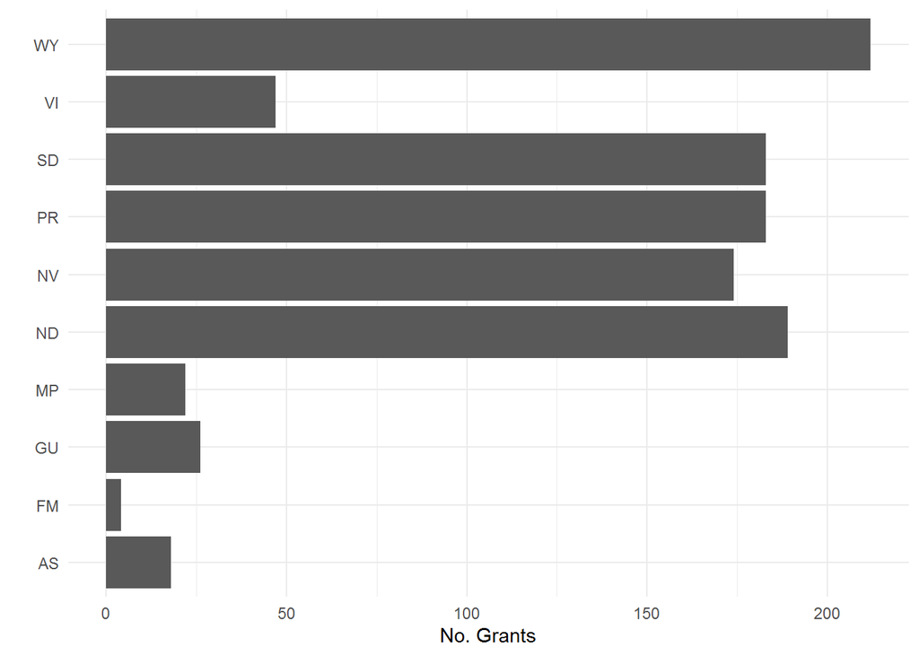

```r
# Fewest grants received
grants_df_calcs %>%
   group_by(InstState) %>%
   summarize(NState = length(InstState)) %>%
   ungroup() %>%
   slice_min(NState, n = 10) %>%
   create_barplot("NState", "InstState", xlabel = "No. Grants")
```

By far, New York and California get the largest number of grants. These are the two of the most populous states with an enormous number of higher education and cultural institutions, so this result makes sense. Washington, DC, is not a state but among the most awarded, likely because the national capitol is a center of cultural research and preservation projects.

The jurisdictions recieving the fewest awards are US territories and low-population states in the western plains of the US. These areas may be deprioritized because of low population, low number of organizations supporting applicants, and in the case of US territories separation from the mainland and perception as “Not American”.

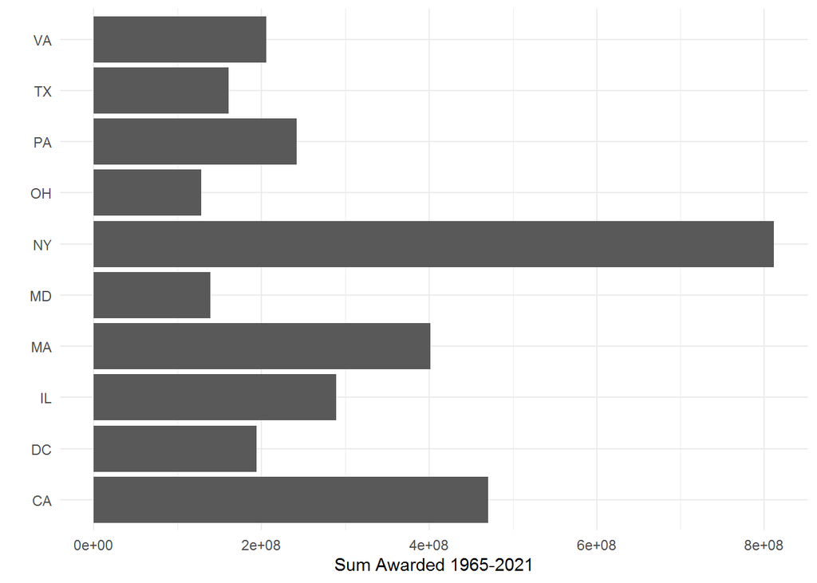

```r
# Most grants received
grants_df_calcs %>%
   group_by(InstState) %>%
   summarize(AwardSum = sum(AwardTotal)) %>%
   ungroup() %>%
   slice_max(AwardSum, n = 10) %>%
   create_barplot("AwardSum", "InstState", xlabel = "Sum Awarded 1965-2021")
```

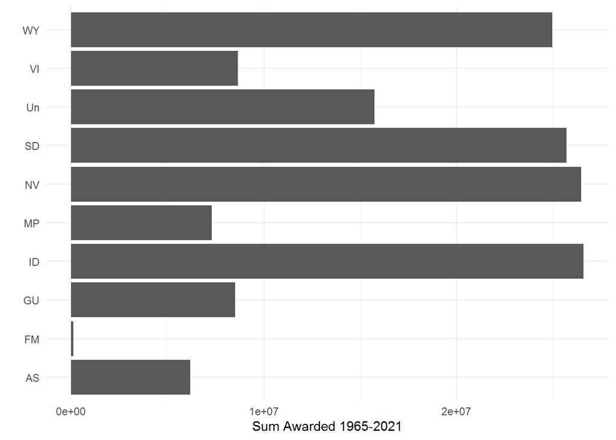

```r
# Fewest grants received
grants_df_calcs %>%
   group_by(InstState) %>%
   summarize(AwardSum = sum(AwardTotal)) %>%
   ungroup() %>%
   slice_min(AwardSum, n = 10) %>%
   create_barplot("AwardSum", "InstState", xlabel = "Sum Awarded 1965-2021")
```

Repeating the analysis by the total grant amount awarded by jurisdiction, the trend is similar as for number of grants. New York, California, and Massachusetts are the top three awardees. Nine states rank in the top 10 in both award number and award amount; North Carolina receives more grants, but Maryland receives more funds.

For the lowest funding amounts, again 6 terriroties and foreign jurisdictions are among these, as well as 4 states in the western plains region. Two jurisdictions are different between the plots for number of grants and award totals. With respect to grants to terriroties and foreign institutions, Puerto Rico receives 8th fewest grant awards, but receives enough funding to escape the bottom 10. The combined foreign jurisdictions with state “Unknown” receive more grants, but total the 6th least funding, only surpassing smaller and more distant territories. Looking at US states, North Dakota has 9th fewest awards, but receives enough funding to surpass Idaho.

# Grant Analysis Part 3: How much are we talking?

## Award as percent Original Approval

Plotting a histogram of AwardOriginal_pct, we see that the scae has been condensed from hundreds of thousands of dollars to a 0-200% of the original approved amount, with the vast bulk of grants receiving approx 100% or less of the original amount.

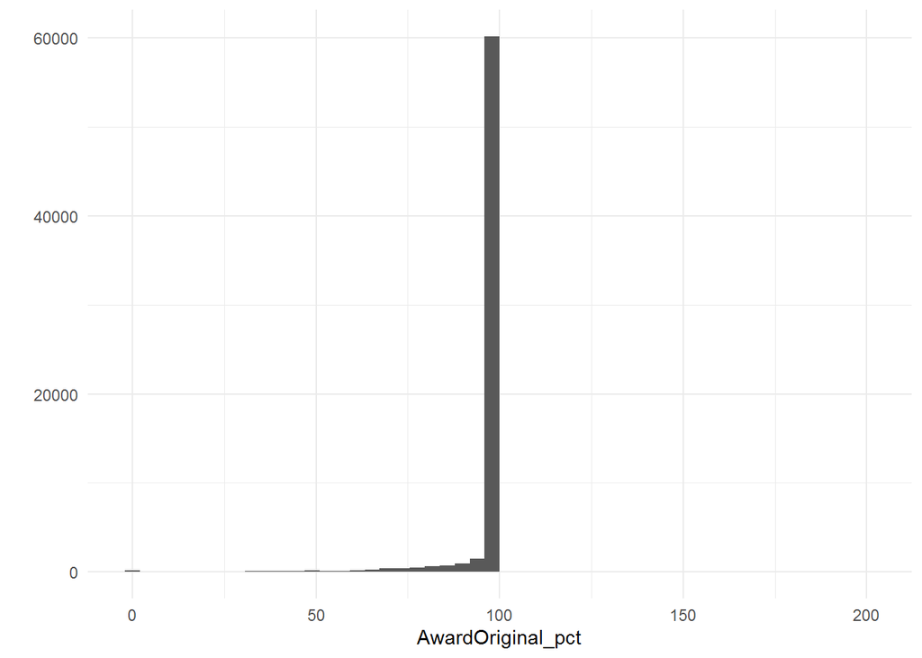

```r
create_hist(grants_df_calcs, "AwardOriginal_pct")
```

The vast majority of grantees are getting the full amount of their award or close enough to share the histogram bin. For a better look at the minority that get a different amount from the initially approved amount, let’s plot the y-axis on a log scale.

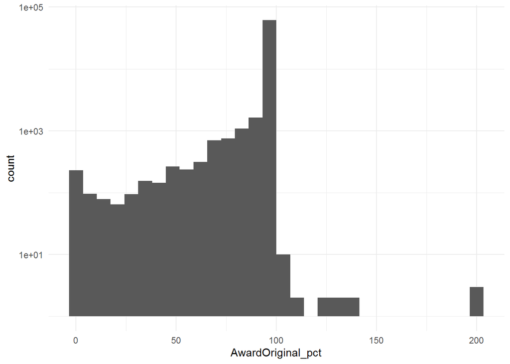

```r
grants_df_calcs %>%
  ggplot(aes(x = AwardOriginal_pct)) +
      geom_histogram() +
      scale_y_log10() +
      theme_minimal()
```

Zooming in on the lower-frequency values shows that the vast majority of grantees who got a different amount than the initially approved amount got less. Very few got more, and those top out at double the original amount.

Is this related to match awards?

```r
grants_df_calcs %>%
   mutate(Award_100 = case_when(
      AwardTotal_pct == 100 ~ "Exact",
      AwardTotal_pct < 100 ~ "Less",
      AwardTotal_pct > 100 ~ "More"
   ))  %>%
   group_by(MatchReqd, Award_100) %>%
   summarise(count = n()) %>%
 #  arrange(desc(count)) %>%
   ungroup()
```

| MatchReqd | Award_100 | count |
| --- | --- | --- |
| FALSE | Exact | 49441 |
| FALSE | Less | 8926 |
| FALSE | More | 46 |
| FALSE | NA | 24 |
| TRUE | Exact | 5890 |
| TRUE | Less | 2801 |
| TRUE | More | 25 |

## Match requirements: How successful are they?

Some grants are contingent on raising matching funds from other sources, such as individual donors, philanthropic foundations, or state or federal agencies other than the granting agency (in this case NEH).

How many grants require matching funds to complete the award, and how successful are they at meeting the requirement for matching funds? Has this changed over time?

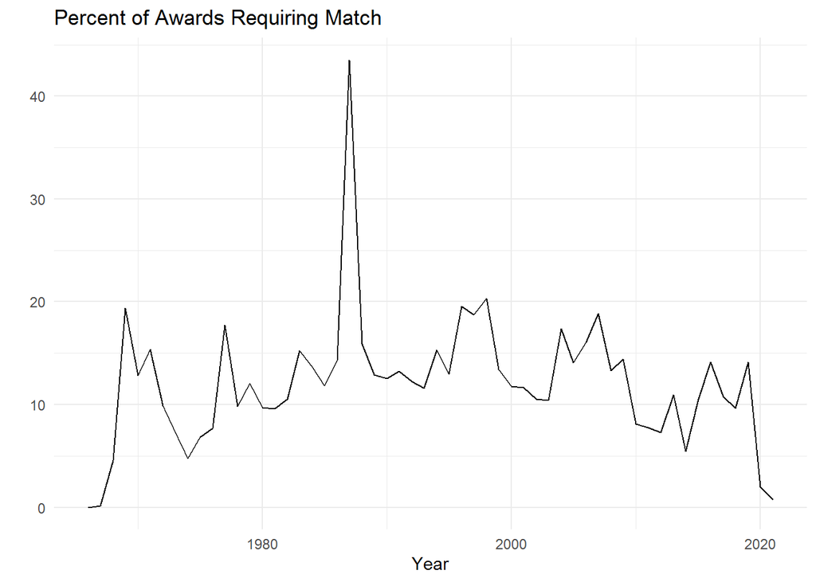

```r
grants_match_summary <-
grants_df_calcs %>%
   group_by(YearAwarded) %>%
   summarize(across(c(MatchReqd, MatchMet), ~sum(., na.rm = T)),
             MatchMet_pct = 100 * MatchMet / MatchReqd,
             MatchReq_pct = 100 * sum(MatchReqd, na.rm = T)/ n()) %>%
   ungroup()

create_yearplot(grants_match_summary, "MatchReq_pct", toptitle = "Percent of Awards Requiring Match")
```

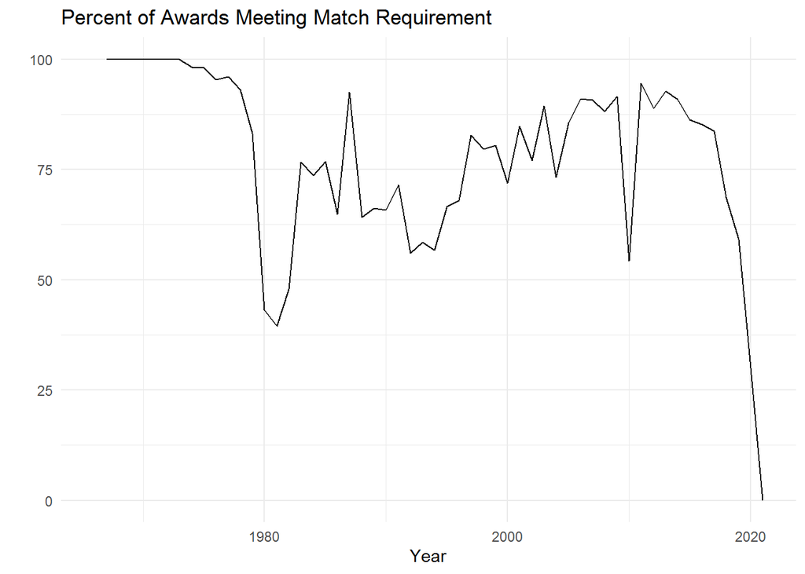

```r
create_yearplot(grants_match_summary, "MatchMet_pct", toptitle = "Percent of Awards Meeting Match Requirement")
```

The proportion of awards requiring a match generally hovers around 15% of total grants. The proportion of grantees meeting their match award amount is more variable, generally 75% but with a wide band of variation. The grants meeting their match amount falls precipitously in the most recent 5 years; these grant cycles may not be complete or the paperwork confirming fundraising may not have been completely processed yet.

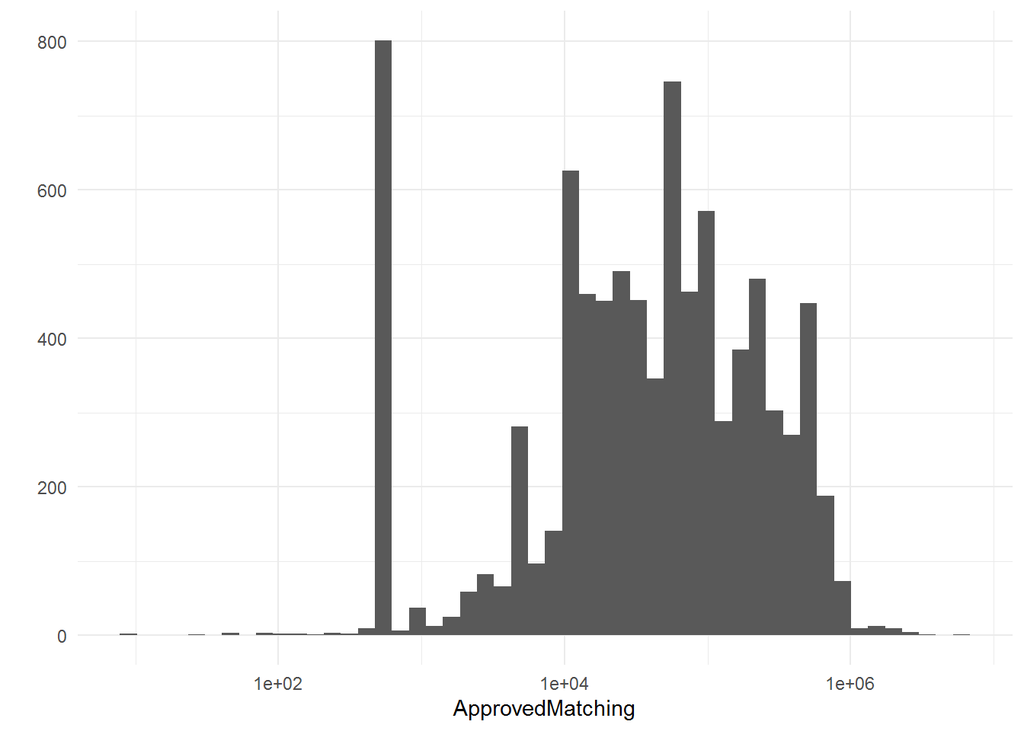

```r
grants_df_calcs %>%
   filter(! is.na(ApprovedMatching),
          ! ApprovedMatching == 0) %>%
   create_hist_log("ApprovedMatching")
```

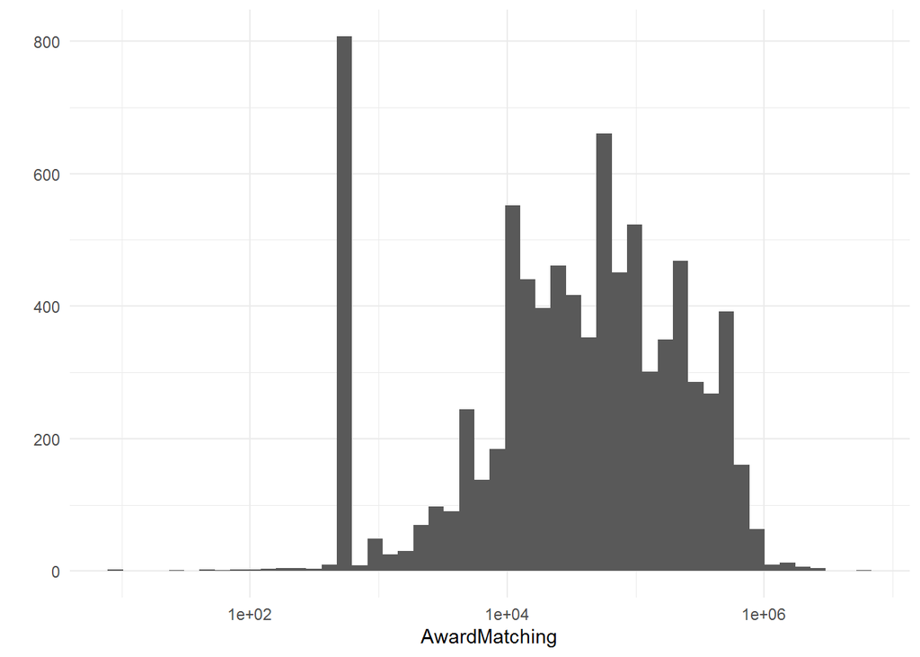

```r
grants_df_calcs %>%
   filter(! is.na(AwardMatching),
          ! AwardMatching == 0) %>%
   create_hist_log("AwardMatching")
```

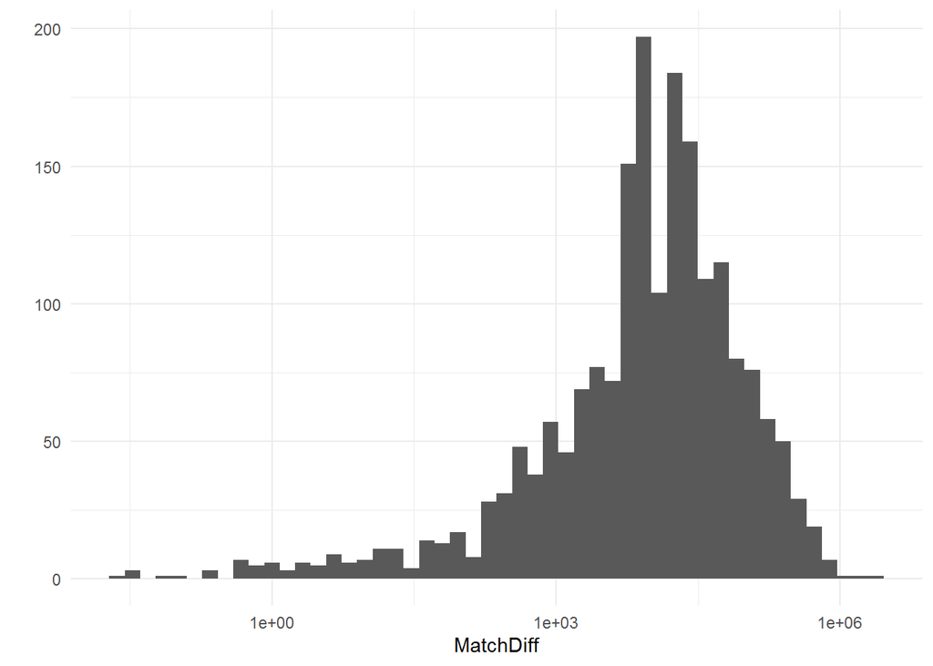

```r
grants_df_calcs %>%
   # filter by nonzero approved and remove NAs from calc; award may be 0
   filter(! is.na(ApprovedMatching),
          ! is.na(AwardMatching),
          ! ApprovedMatching == 0) %>%
   # calculate difference between approved & raised
   mutate(MatchDiff = ApprovedMatching - AwardMatching) %>%
   # remove zero  & negative results to quiet log plot errors
   filter(!MatchDiff <= 0) %>%
   create_hist_log("MatchDiff")
```

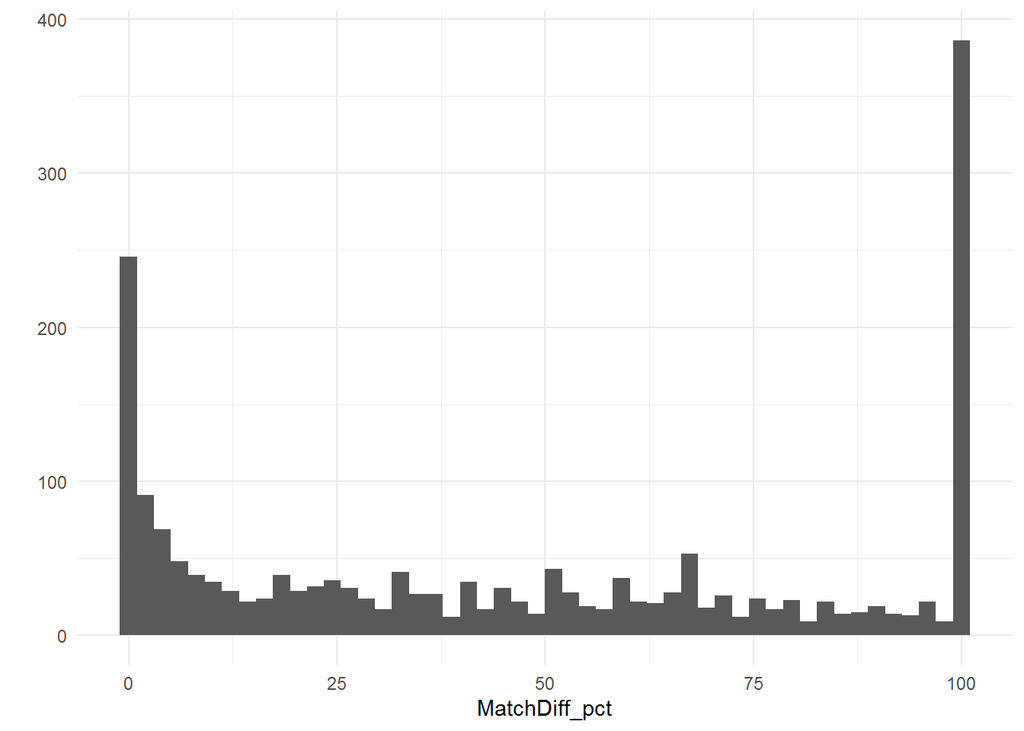

```r
grants_df_calcs %>%
   # filter by nonzero approved and remove NAs from calc; award may be 0
   filter(! is.na(ApprovedMatching),
          ! is.na(AwardMatching),
          ! ApprovedMatching == 0) %>%
   # calculate percent difference between approved & raised
   mutate(MatchDiff = ApprovedMatching - AwardMatching,
          MatchDiff_pct = 100 * MatchDiff / ApprovedMatching) %>%
   # remove zero & negative results to focus on shortfalls
   filter(!MatchDiff_pct <= 0) %>%
   create_hist("MatchDiff_pct")
```

Are these shortfalls correlated with grant amounts?

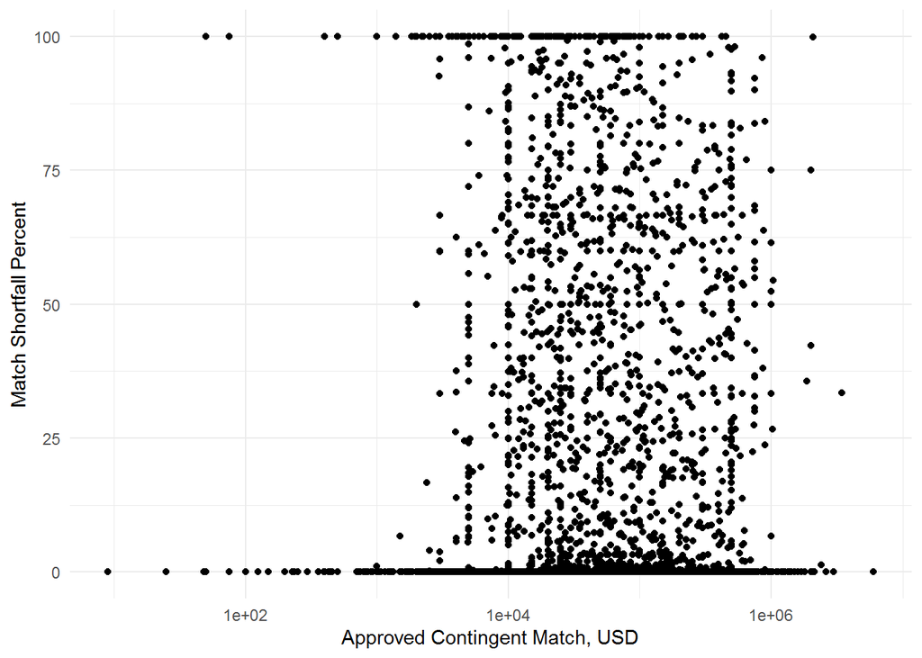

```r
grants_df_calcs %>%
   # filter by nonzero approved and remove NAs from calc; award may be 0
   filter(! is.na(ApprovedMatching),
          ! is.na(AwardMatching),
          ! ApprovedMatching == 0) %>%
   # calculate percent difference between approved & raised
   mutate(MatchDiff = ApprovedMatching - AwardMatching,
          MatchDiff_pct = 100 * MatchDiff / ApprovedMatching) %>%
   # remove single negative result
   filter(!MatchDiff_pct < 0) %>%
   ggplot(aes(x = ApprovedMatching,
              y = MatchDiff_pct)) +
   geom_point() +
   scale_x_log10() +
   labs(x = "Approved Contingent Match, USD",
         y = "Match Shortfall Percent") +
   theme_minimal()
```

Shortfalls appear concentrated among grant amounts of $5,000 to $500,000. Grantees with smaller match requirements are somewhat more likely to raise either no matching funds or the full amount, and conversely institutional grants over $1 million very rarely have significant fundraising shortfalls.

## Do amounts trend by grantee or discipline properties?

### Applicant Type: Organization vs Individual

```r
grants_award_typesum <-
grants_df_calcs %>%
   group_by(Decade) %>%
   mutate(NTotal = length(ApplicantType),
          AwardSum = sum(AwardTotal)) %>%
   group_by(ApplicantType, NTotal, AwardSum, Decade) %>%
   summarise(TypeCount = n(), TypeAwardTotal = sum(AwardTotal)) %>%
   mutate(TypePercent = 100 * TypeCount / NTotal,
          TypeAwardPercent = 100 * TypeAwardTotal / AwardSum) %>%
   arrange(Decade) %>%
   ungroup() %>%
   select(Decade, ApplicantType, TypeCount, TypePercent, TypeAwardTotal, TypeAwardPercent)
grants_award_typesum
```

| Decade | ApplicantType | TypeCount | TypePercent | TypeAwardTotal | TypeAwardPercent |
| --- | --- | --- | --- | --- | --- |
| 1960-1969 | 1 | 519 | 49.47569 | 10615528 | 76.131931 |
| 1960-1969 | 2 | 530 | 50.52431 | 3328067 | 23.868069 |
| 1970-1979 | 1 | 9529 | 62.02968 | 756585037 | 92.093101 |
| 1970-1979 | 2 | 5833 | 37.97032 | 64958627 | 7.906899 |
| 1980-1989 | 1 | 10847 | 55.09727 | 1050187346 | 92.794401 |
| 1980-1989 | 2 | 8840 | 44.90273 | 81548332 | 7.205599 |
| 1990-1999 | 1 | 5977 | 47.30136 | 1098537267 | 92.877148 |
| 1990-1999 | 2 | 6659 | 52.69864 | 84248052 | 7.122852 |
| 2000-2009 | 1 | 6624 | 68.86371 | 1008288690 | 93.024771 |
| 2000-2009 | 2 | 2995 | 31.13629 | 75603993 | 6.975229 |

[output cut: 4 more lines]

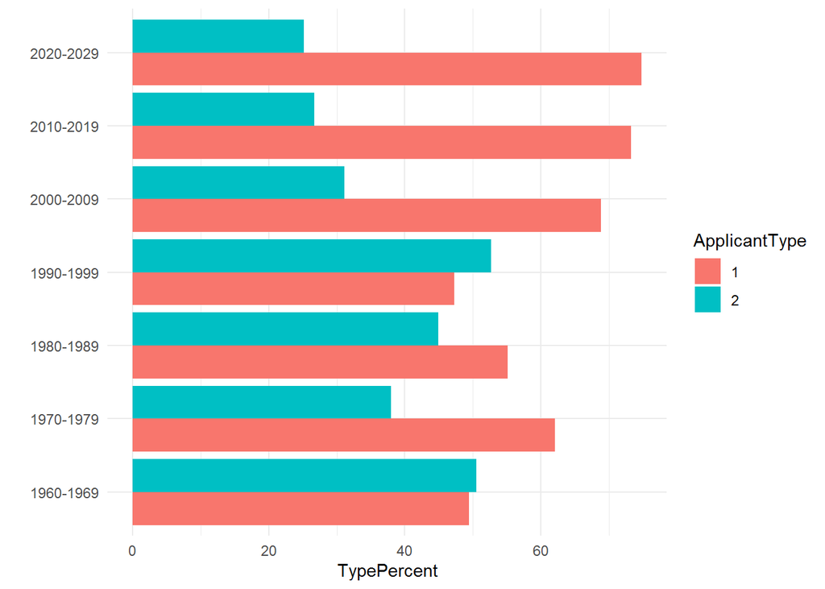

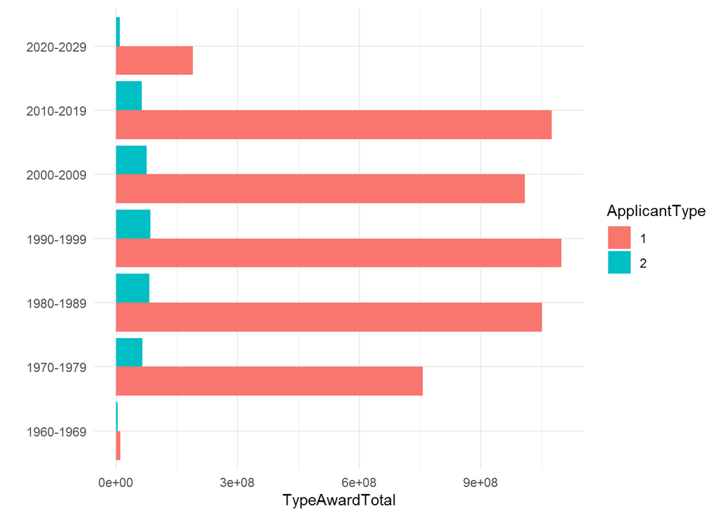

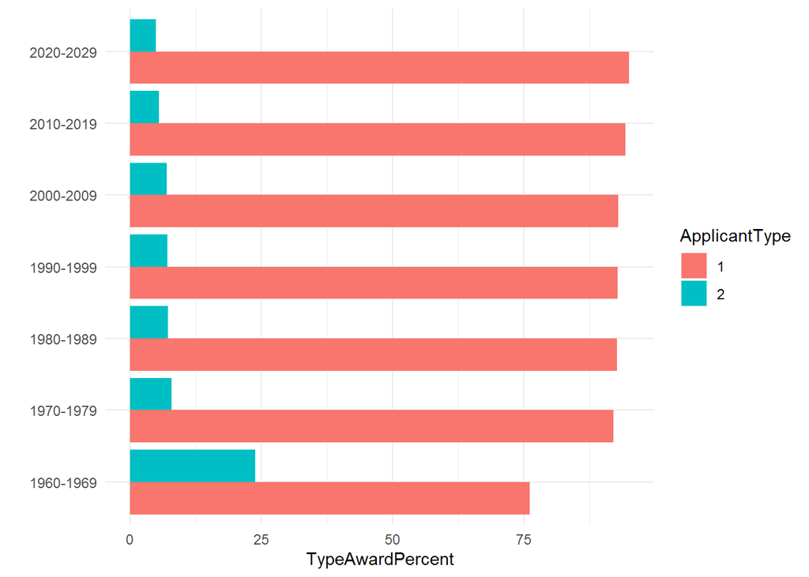

```r
TypeAwardCols <- c("TypePercent", "TypeAwardTotal", "TypeAwardPercent")

map(TypeAwardCols, ~ grants_award_typesum %>%
   create_barplot_grouped(.x, "Decade", "ApplicantType"))
```

Two main observations on this data:  
1. The proportion of applicant types has shifted dramatically from the 1990s to today from a roughly 1:1 ratio between organizations and individuals to a 3:1 ratio.  
2. During this period, award totals for individuals have dropped by $20 million while organizational awards have remained stable. This inches the percent of funds disbursed to individuals from 8% per decade to 5% per decade over the life of the grant program.

These observations confirm the interpretation of the histogram distribution in the initial analysis: There is a shift away from individual awards towards institutional grantees both in number of awards and amount.

### Organization Type

This table shows the top two organization types awarded grants in each decade.

```r
grants_df_calcs %>%
   group_by(Decade) %>%
   mutate(NTotal = length(OrganizationType),
          AwardSum = sum(AwardTotal)) %>%
   group_by(OrganizationType, NTotal, AwardSum, Decade) %>%
   summarise(TypeCount = n(), TypeAwardTotal = sum(AwardTotal)) %>%
   mutate(TypePercent = 100 * TypeCount / NTotal,
          TypeAwardPercent = 100 * TypeAwardTotal / AwardSum) %>%
   ungroup() %>%
   group_by(Decade) %>%
   slice_max(TypeCount, n = 2) %>%
   arrange(Decade) %>%
   ungroup() %>%
   select(Decade, OrganizationType, TypeCount, TypePercent, TypeAwardTotal, TypeAwardPercent)
```

| Decade | OrganizationType | TypeCount | TypePercent | TypeAwardTotal | TypeAwardPercent |
| --- | --- | --- | --- | --- | --- |
| 1960-1969 | University | 354 | 33.74643 | 3548726 | 25.450583 |
| 1960-1969 | Four-Year College | 353 | 33.65110 | 3302540 | 23.684997 |
| 1970-1979 | University | 4036 | 26.27262 | 150844029 | 18.361048 |
| 1970-1979 | Four-Year College | 3861 | 25.13345 | 143928219 | 17.519242 |
| 1980-1989 | Unknown | 4695 | 23.84822 | 26068551 | 2.303413 |
| 1980-1989 | Four-Year College | 4098 | 20.81577 | 200235775 | 17.692804 |
| 1990-1999 | Unknown | 3204 | 25.35613 | 26841904 | 2.269381 |
| 1990-1999 | Four-Year College | 2819 | 22.30928 | 193782198 | 16.383548 |
| 2000-2009 | Four-Year College | 2359 | 24.52438 | 165196966 | 15.241081 |
| 2000-2009 | University | 2199 | 22.86100 | 183001533 | 16.883732 |

[output cut: 4 more lines]

For 1980s and 1990s, the Type Unknown received the largest number of awards, receiving nearly 1/4 of the grants but only 2% of funds. Based on the analysis of award number and amounts above, this points to individual awardees being the recipients of these grants.

### Disciplines

```r
grants_df_calcs %>%
   group_by(Decade) %>%
   mutate(NTotal = length(PrimaryDiscipline),
          AwardSum = sum(AwardTotal)) %>%
   group_by(PrimaryDiscipline, NTotal, AwardSum, Decade) %>%
   summarise(TypeCount = n(), TypeAwardTotal = sum(AwardTotal)) %>%
   mutate(TypePercent = 100 * TypeCount / NTotal,
          TypeAwardPercent = 100 * TypeAwardTotal / AwardSum) %>%
   ungroup() %>%
   group_by(Decade) %>%
   slice_max(TypeCount, n = 2) %>%
   arrange(Decade) %>%
   ungroup() %>%
   select(Decade, PrimaryDiscipline, TypeCount, TypePercent, TypeAwardTotal, TypeAwardPercent)
```

| Decade | PrimaryDiscipline | TypeCount | TypePercent | TypeAwardTotal | TypeAwardPercent |
| --- | --- | --- | --- | --- | --- |
| 1960-1969 | History, General | 252 | 24.022879 | 2620279 | 18.791990 |
| 1960-1969 | Interdisciplinary Studies, General | 192 | 18.303146 | 4681073 | 33.571492 |
| 1970-1979 | Interdisciplinary Studies, General | 5546 | 36.102070 | 519925020 | 63.286353 |
| 1970-1979 | History, General | 1382 | 8.996224 | 44096772 | 5.367551 |
| 1980-1989 | U.S. History | 2804 | 14.242901 | 98428943 | 8.697167 |
| 1980-1989 | Interdisciplinary Studies, General | 1745 | 8.863717 | 391366502 | 34.581087 |
| 1990-1999 | U.S. History | 1504 | 11.902501 | 161241372 | 13.632345 |
| 1990-1999 | Interdisciplinary Studies, General | 1236 | 9.781576 | 393797249 | 33.294060 |
| 2000-2009 | U.S. History | 1779 | 18.494646 | 178911739 | 16.506407 |
| 2000-2009 | Interdisciplinary Studies, General | 1166 | 12.121842 | 395977602 | 36.532916 |

[output cut: 4 more lines]

The most common disciplines awarded grants are U.S. History and Interdisciplinary Studies. These comprise 20-30% of grants and 40-50% of disbursed funds.

### Supplemenal Awards

Relatively few grantees receive supplemental awards. However, they can be substantial as noted by a max value of $5 million.

```r
grants_df_calcs %>%
   group_by(Decade) %>%
   mutate(NTotal = length(Supplements),
          SupplementGet = case_when(
             SupplementAmount == 0 ~ FALSE,
             SupplementAmount > 0 ~ TRUE
          )) %>%
   group_by(SupplementGet, NTotal, Decade) %>%
   summarise(TypeCount = n(),
             "Mean Supplement" = mean(SupplementAmount),
             "Median Supplement" = median(SupplementAmount),
             "Max Supplement" = max(SupplementAmount),
             "Min Supplement" = min(SupplementAmount)) %>%
   mutate(TypePercent = 100 * TypeCount / NTotal) %>%
   ungroup() %>%
   filter(SupplementGet == TRUE) %>%
   select(Decade, SupplementGet, TypeCount, TypePercent, "Mean Supplement", "Median Supplement","Max Supplement", "Min Supplement")  %>%
   arrange(Decade)
```

| Decade | SupplementGet | TypeCount | TypePercent | Mean Supplement | Median Supplement | Max Supplement | Min Supplement |
| --- | --- | --- | --- | --- | --- | --- | --- |
| 1970-1979 | TRUE | 2 | 0.01301914 | 17390.5 | 17390.5 | 30495 | 4286 |
| 1980-1989 | TRUE | 397 | 2.01655915 | 176136.1 | 50000.0 | 2330845 | 219 |
| 1990-1999 | TRUE | 476 | 3.76701488 | 417006.1 | 221415.0 | 3671285 | 109 |
| 2000-2009 | TRUE | 308 | 3.20199605 | 862901.6 | 973788.5 | 3883077 | 213 |
| 2010-2019 | TRUE | 248 | 3.36043360 | 969239.0 | 811565.0 | 5000000 | 560 |

```r
# associated disciplines/org types?
```

```r
grants_df_calcs %>%
   mutate(SupplementGet = case_when(
             SupplementAmount == 0 ~ FALSE,
             SupplementAmount > 0 ~ TRUE
          )) %>%
   filter(SupplementGet == TRUE) %>%

   group_by(Decade) %>%
   mutate(NTotal = length(PrimaryDiscipline),
          AwardSum = sum(SupplementAmount)) %>%
   group_by(PrimaryDiscipline, NTotal, AwardSum, Decade) %>%
   summarise(TypeCount = n(), TypeAwardTotal = sum(SupplementAmount)) %>%
   mutate(TypePercent = 100 * TypeCount / NTotal,
          TypeAwardPercent = 100 * TypeAwardTotal / AwardSum) %>%
   ungroup() %>%
   group_by(Decade) %>%
   slice_max(TypeCount, n = 2) %>%
   arrange(Decade) %>%
   ungroup() %>%
   select(Decade, PrimaryDiscipline, TypeCount, TypePercent, TypeAwardTotal, TypeAwardPercent)
```

| Decade | PrimaryDiscipline | TypeCount | TypePercent | TypeAwardTotal | TypeAwardPercent |
| --- | --- | --- | --- | --- | --- |
| 1970-1979 | Architecture | 1 | 50.00000 | 4286 | 12.322820 |
| 1970-1979 | Comparative Religion | 1 | 50.00000 | 30495 | 87.677180 |
| 1980-1989 | Interdisciplinary Studies, General | 127 | 31.98992 | 42012799 | 60.081777 |
| 1980-1989 | U.S. History | 43 | 10.83123 | 7111456 | 10.169970 |
| 1990-1999 | Interdisciplinary Studies, General | 226 | 47.47899 | 153168414 | 77.164910 |
| 1990-1999 | U.S. History | 53 | 11.13445 | 8557575 | 4.311232 |
| 2000-2009 | Interdisciplinary Studies, General | 206 | 66.88312 | 237675433 | 89.427754 |
| 2000-2009 | U.S. History | 37 | 12.01299 | 15917289 | 5.989039 |
| 2010-2019 | Interdisciplinary Studies, General | 131 | 52.82258 | 187333676 | 77.935135 |
| 2010-2019 | U.S. History | 37 | 14.91935 | 13572540 | 5.646490 |

As with the overall grant distribution, supplemental awards are granted overwhelmingly to the disciplines of U.S. History and Interdisciplinary Studies. Together, these comprise 40-80% of supplemental awards and 70-95% of disbursed supplemental funds. These numbers signify stronger representation of these fields in supplemental grants than in general awards.

# Conclusions and Future Work

This analysis concludes that NEH grant activity primarily supports work at educational and research institutions in the disciplines of U.S. History and Interdisciplinary Studies. Grant activity peaked in number of awards in the 1980s, and since that time total funding has stagnated while undergoing a shift from individual to institutional recipients.

Awards are concentrated in number and total amount in highly populous states with many educational and cultural institutions. Grantees receiving the fewest awards and least funds tended to be US territories or foreign institutions and low-population states in the Western US.

About 15% of awards require recipients to raise matching funds. While most recipients do meet their full match potential, grantees have the most difficulty fundraising the full match amount when it is between $5,000 and $500,000. Almost no grants of $1+ million fell short of matching fund goals. This suggests institutional fundraising support may be critical to successfully capturing all matching funds.

Supplemental awards are rare (2-3%), but can be substantial and overwhelmingly support the same primary fields as the general grant process.

Future work includes adjusting the data input function to pull the latest copy of the data from the Data.gov website and incorporating the data cleaning routine into the initial load script. Some of the analysis generation could be automated into functions with additional conceptual time to correctly scale the function to flexibly fit with subsequent operations. Additional analysis will look at the full set of disciplines instead of only the Primary Discipline, relationships between Matching grant performance and grantee characteristics, and analysis of foreign grants.